# Tips and tricks

```python
import matplotlib.pyplot as plt
import numpy as np
import pandas as pd
from cycler import cycler

from mxlpy import plot
```

## Renaming plots arguments

The easiest way to rename plot arguments, e.g. for `LaTeX` display, is to work on the `pandas.DataFrame` directly.  
This conveniently offers a `rename` method, to which you can supply a dictionary of desired names.

```python
x = np.linspace(0, np.pi, 100)
data = pd.DataFrame(
    {
        "x1": np.sin(x),
        "x2": np.sin(x * 2),
        "x3": np.sin(x * 4),
    }
)

fig, ax = plot.lines(
    data.rename(
        columns={
            "x1": r"$x_{1}$",
            "x2": r"$x_{2}$",
            "x3": r"$x_{3}$",
        }
    )
)
ax.set(xlabel="time / a.u.", ylabel="concentration / a.u.")
plt.show()
```

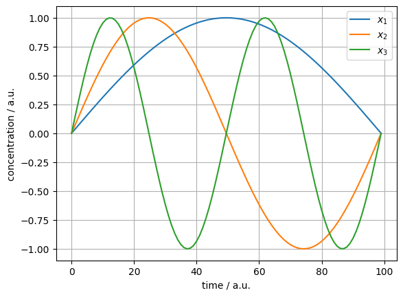

## Custom plot styling

To change the style of plot elements, we recommend using `plot.context`, which is a convenience wrapper around `plt.rc_context`, see [the matplotlib documentation](https://matplotlib.org/stable/users/explain/customizing.html).

That way, our plotting routines can easily be re-used with completely different styling options.

We opted for this way of styling plots so that you can use new features introduced by `matplotlib` immediately and don't have to wait for us to support every single update an every single plotting function.

```python
x = np.linspace(0, np.pi, 100)
data = pd.DataFrame(
    {
        "x1": np.sin(x),
        "x2": np.sin(x * 2),
        "x3": np.sin(x * 4),
    }
)

with plot.context(
    colors=["r", "g", "b"],
    linewidth=2,
):
    fig, ax = plot.lines(data)
    ax.set(xlabel="time", ylabel="amplitude")

ax.legend()
plot.show()
```

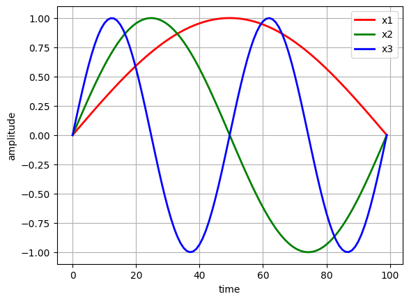

## Advanced plot styling

In case the our convenience arguments are not enough, you can use the entirety of the [the matplotlib rc customizing arguments](https://matplotlib.org/stable/users/explain/customizing.html) using the `rc` keyword argument of `plot.context`.

Here, you have to spell out the exact name that `matplotlib` expects, e.g. `axes.prop_cycle` instead of just `colors` in case that was everything you wanted to change.

> Hint: watch out for the difference between `cycler + cycler` and `cycler * cycler`.

```python
x = np.linspace(0, np.pi, 100)
data = pd.DataFrame(
    {
        "x1": np.sin(x),
        "x2": np.sin(x * 2),
        "x3": np.sin(x * 4),
    }
)

with plot.context(
    rc={"axes.prop_cycle": cycler(color=["r", "b"]) + cycler(linestyle=["-", "--"])},
):
    plot.lines(data, ax=plot.one_axes(figsize=(3, 3))[1])
    plot.show()

with plot.context(
    rc={"axes.prop_cycle": cycler(color=["r", "b"]) * cycler(linestyle=["-", "--"])},
):
    plot.lines(data, ax=plot.one_axes(figsize=(3, 3))[1])
    plot.show()
```

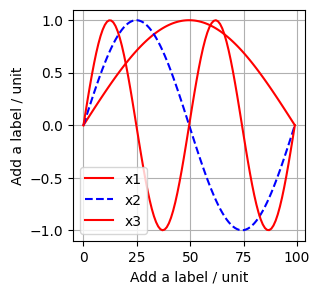

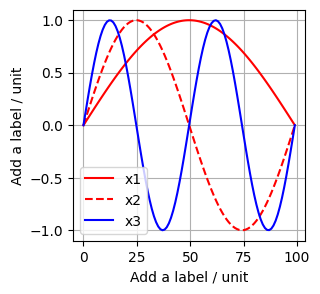